# Midterm Project

Nathalie Garimella

2/10/2021

# Midterm

## Define Your Research Question (10 points)

> *Define your research question below. What about the data interests you? What is a specific question you want to find out about the data?*

I found this BoardGames dataset on the TidyTuesday github page, and I thought it looked really interesting because I love playing board games but I had no idea there were so many of them! I was interested to learn more about what made a board game popular, when there were so many that I had never heard of. Therefore, I came up with the following research question: How does minimum length of play affect average rating of board game on Board Game Geek? How does this change if you stratify by minimum age of player? I was interested in whether people prefer longer or shorter games, and if this changes based on the age group that is the target audience of the game.

> *Given your question, what is your expectation about the data?*

I would expect that overall, longer minimum playtime would lead to lower ratings because aside from committed board game enthusiasts, the casual player might either not want to try the game, or might get bored of it before they can learn to enjoy it. I would think that this effect might be more pronounced among games with a lower minimum player age, due to the typically lower attention span of children and tweens. Games aimed at an older teenage or adult audience might see less of an effect of minimum playtime on rating since those players might be more willing to devote longer to the process, and also may be more likely to already be enthusiastic board-game fans and therefore more used to playing for longer periods or in a social setting.

## Loading the Data (10 points)

> *Load the data below and use `dplyr::glimpse()` or `skimr::skim()` on the data. You should upload the data file into the `data` directory.*

I got this data from the TidyTuesday github page, and the folder containing the data can be accessed using the following link: https://github.com/rfordatascience/tidytuesday/tree/master/data/2019/2019-03-12

First I will load the BoardGames dataset:

```r
BoardGames <- read.csv("board_games.csv")
head(BoardGames)
```

|  | game_id | description | image | max_players | max_playtime | min_age | min_players | min_playtime | name | playing_time | thumbnail | year_published | artist | category | compilation | designer | expansion | family | mechanic | publisher | average_rating | users_rated |
| --- | --- | --- | --- | --- | --- | --- | --- | --- | --- | --- | --- | --- | --- | --- | --- | --- | --- | --- | --- | --- | --- | --- |
| 1 | 1 | Die Macher is a game about seven sequential political races in different regions of Germany. Players are in charge of national political parties, and must manage limited resources to help their party … | //cf.geekdo-images.com/images/pic159509.jpg | 5 | 240 | 14 | 3 | 240 | Die Macher | 240 | //cf.geekdo-images.com/images/pic159509_t.jpg | 1986 | Marcus Gschwendtner | Economic,Negotiation,Political | NA | Karl-Heinz Schmiel | NA | Country: Germany,Valley Games Classic Line | Area Control / Area Influence,Auction/Bidding,Dice Rolling,Hand Management,Simultaneous Action Selection | Hans im Glück Verlags-GmbH,Moskito Spiele,Valley Games, Inc. | 7.66508 | 4498 |
| 2 | 2 | Dragonmaster is a trick-taking card game based on an older game called Coup d'etat. Each player is given a supply of plastic gems, which represent points. Each player will get to be the dealer for fiv… | //cf.geekdo-images.com/images/pic184174.jpg | 4 | 30 | 12 | 3 | 30 | Dragonmaster | 30 | //cf.geekdo-images.com/images/pic184174_t.jpg | 1981 | Bob Pepper | Card Game,Fantasy | NA | G. W. "Jerry" D'Arcey | NA | Animals: Dragons | Trick-taking | E.S. Lowe,Milton Bradley | 6.60815 | 478 |
| 3 | 3 | Part of the Knizia tile-laying trilogy, Samurai is set in medieval Japan. Players compete to gain the favor of three factions: samurai, peasants, and priests, which are represented by helmet, rice pad… | //cf.geekdo-images.com/images/pic3211873.jpg | 4 | 60 | 10 | 2 | 30 | Samurai | 60 | //cf.geekdo-images.com/images/pic3211873_t.jpg | 1998 | Franz Vohwinkel | Abstract Strategy,Medieval | NA | Reiner Knizia | NA | Asian Theme,Country: Japan,Knizia tile-laying trilogy,Samurai | Area Control / Area Influence,Hand Management,Set Collection,Tile Placement | 999 Games,ABACUSSPIELE,Astrel Games,Ceilikan Jogos,Descartes Editeur,Edge Entertainment,Fantasy Flight Games,Galakta,Hans im Glück Verlags-GmbH,Hobby Japan,Lacerta,Lautapelit.fi,Rio Grande Games,Skand… | 7.44119 | 12019 |
| 4 | 4 | When you see the triangular box and the luxurious, large blocks, you can tell this game was designed to be beautiful as well as functional. The object of the game is to build pyramids out of the diffe… | //cf.geekdo-images.com/images/pic285299.jpg | 4 | 60 | 12 | 2 | 60 | Tal der Könige | 60 | //cf.geekdo-images.com/images/pic285299_t.jpg | 1992 | NA | Ancient | NA | Christian Beierer | NA | Country: Egypt,Promotional Board Games | Action Point Allowance System,Area Control / Area Influence,Auction/Bidding,Set Collection | KOSMOS | 6.60675 | 314 |
| 5 | 5 | In Acquire, each player strategically invests in businesses, trying to retain a majority of stock. As the businesses grow with tile placements, they also start merging, giving the majority stockholder… | //cf.geekdo-images.com/images/pic342163.jpg | 6 | 90 | 12 | 3 | 90 | Acquire | 90 | //cf.geekdo-images.com/images/pic342163_t.jpg | 1964 | Scott Okumura,Peter Whitley | Economic | NA | Sid Sackson | NA | 3M Bookshelf Series | Hand Management,Stock Holding,Tile Placement | 3M,Avalon Hill,Avalon Hill (Hasbro),Dujardin,Grow Jogos e Brinquedos,PS-Games,Schmidt France,Schmidt International,Schmidt Spiele,Selecta Spel en Hobby,Smart Games, Inc. | 7.35830 | 15195 |
| 6 | 6 | In the ancient lands along the Mediterranean, players attempt to satisfy their unique victory conditions via trade, war and construction. This lavishly produced game contains tons of wooden game compo… | //cf.geekdo-images.com/images/pic28424.jpg | 6 | 240 | 12 | 2 | 240 | Mare Mediterraneum | 240 | //cf.geekdo-images.com/images/pic28424_t.jpg | 1989 | Jean du Poël | Civilization,Nautical | NA | Jean du Poël | NA | Cities: Marseille | Dice Rolling | Historien Spiele Galerie (Historien Spielegalerie) | 6.52534 | 73 |

Then I will check to make sure that the average_rating, min_playtime, and min_age columns are all encoded as numbers and not characters, so that I can do my analysis properly.

```r
glimpse(BoardGames)
```

```
## Rows: 10,532
## Columns: 22
## $ game_id        <int> 1, 2, 3, 4, 5, 6, 7, 8, 9, 10, 11, 12, 13, 14, 15, 16,…
## $ description    <chr> "Die Macher is a game about seven sequential political…
## $ image          <chr> "//cf.geekdo-images.com/images/pic159509.jpg", "//cf.g…
## $ max_players    <int> 5, 4, 4, 4, 6, 6, 2, 5, 4, 6, 7, 5, 4, 4, 6, 4, 2, 8, …
## $ max_playtime   <int> 240, 30, 60, 60, 90, 240, 20, 120, 90, 60, 45, 60, 120…
## $ min_age        <int> 14, 12, 10, 12, 12, 12, 8, 12, 13, 10, 13, 12, 10, 10,…
## $ min_players    <int> 3, 3, 2, 2, 3, 2, 2, 2, 2, 2, 2, 2, 3, 3, 2, 3, 2, 2, …
## $ min_playtime   <int> 240, 30, 30, 60, 90, 240, 20, 120, 90, 60, 45, 45, 60,…
## $ name           <chr> "Die Macher", "Dragonmaster", "Samurai", "Tal der Köni…
## $ playing_time   <int> 240, 30, 60, 60, 90, 240, 20, 120, 90, 60, 45, 60, 120…
## $ thumbnail      <chr> "//cf.geekdo-images.com/images/pic159509_t.jpg", "//cf…
## $ year_published <int> 1986, 1981, 1998, 1992, 1964, 1989, 1978, 1993, 1998, …
## $ artist         <chr> "Marcus Gschwendtner", "Bob Pepper", "Franz Vohwinkel"…
## $ category       <chr> "Economic,Negotiation,Political", "Card Game,Fantasy",…
## $ compilation    <chr> NA, NA, NA, NA, NA, NA, NA, NA, NA, NA, NA, NA, "CATAN…
## $ designer       <chr> "Karl-Heinz Schmiel", "G. W. \"Jerry\" D'Arcey", "Rein…
## $ expansion      <chr> NA, NA, NA, NA, NA, NA, NA, NA, NA, "Elfengold,Elfenla…
## $ family         <chr> "Country: Germany,Valley Games Classic Line", "Animals…
## $ mechanic       <chr> "Area Control / Area Influence,Auction/Bidding,Dice Ro…
## $ publisher      <chr> "Hans im Glück Verlags-GmbH,Moskito Spiele,Valley Game…
## $ average_rating <dbl> 7.66508, 6.60815, 7.44119, 6.60675, 7.35830, 6.52534, …
## $ users_rated    <int> 4498, 478, 12019, 314, 15195, 73, 2751, 186, 1263, 672…
```

Lastly, I’ll check for NA values in my columns of interest (again, average_rating, min_playtime, and min_age):

```r
#I just found this code/refreshed my memory using the help function in RStudio
anyNA(BoardGames$min_age)
```

```
## [1] FALSE
```

```r
anyNA(BoardGames$min_playtime)
```

```
## [1] FALSE
```

```r
anyNA(BoardGames$average_rating)
```

```
## [1] FALSE
```

There are no missing values encoded as NA for my three columns of interest.

> *If there are any quirks that you have to deal with `NA` coded as something else, or it is multiple tables, please make some notes here about what you need to do before you start transforming the data in the next section.*

Note: I thought I did not have NA values, but once I started exploring the data further, it turned out that there was minimum age data encoded as zero, and minimum playtime data encoded as zero. It was unsure if this meant that there really was no minimum age/playtime or just that the data was missing. I chose to create a separate category for these values when I categorized both of those variables. I looked at them briefly in my tables, and excluded them from my graphs, using the category I had created.

> **Make sure your data types are correct!**

Done! See above.

## Transforming the data (15 points)

> *If the data needs to be transformed in any way (values recoded, pivoted, etc), do it here. Examples include transforming a continuous variable into a categorical using `case_when()`, etc.*

*The three main things I’d like to do to my dataframe to make it more useful for this project are:*

1. Move the columns I will be using the the beginning of the table, because the 2nd column containing the description of the board-game is very long and makes the table unwieldy to look at quickly using functions like head, and doesn’t show up well in the final html file.
2. Divide minimum playtime into groups, to ease analysis; this will involve making a new categorical variable for minimum playtime.
3. Divide minimum age into categories for my analysis; I’ll need to look at the range and distribution of ages first, and then choose appropriate category breaks and add a new column with the re-coded categorical variable. This will allow me to subset for the next question.

> *Subset of the data and think of a question to answer the subset*

I will be sub-setting the data into age groups in order to look not only the correlation between minimum playtime and average rating overall, but also in each of the separate age groups.

> *Bonus points (5 points) for datasets that require merging of tables, but only if you reason through whether you should use `left_join`, `inner_join`, or `right_join` on these tables. No credit will be provided if you don’t.*

I don’t anticipate needing to merge tables for this project, as the BoardGames dataset came in a complete form.

```r
#First, I am rearranging the columns in the table. This code came from Dr. Minnier and Dr. Niederhausen's "An Introduction to R and RStudio for Exploratory Data Analysis" Part 2 slides. https://jminnier-berd-r-courses.netlify.app/01-intro-r-eda/01_intro_r_eda_part2#1

BoardGames_V1 <- BoardGames %>%
  relocate(min_age)
BoardGames_V1 <- BoardGames_V1 %>%
  relocate(min_playtime, .before = game_id)
BoardGames_V1 <- BoardGames_V1 %>%
  relocate(average_rating, .before = game_id)
head(BoardGames_V1)
```

|  | min_age | min_playtime | average_rating | game_id | description | image | max_players | max_playtime | min_players | name | playing_time | thumbnail | year_published | artist | category | compilation | designer | expansion | family | mechanic | publisher | users_rated |
| --- | --- | --- | --- | --- | --- | --- | --- | --- | --- | --- | --- | --- | --- | --- | --- | --- | --- | --- | --- | --- | --- | --- |
| 1 | 14 | 240 | 7.66508 | 1 | Die Macher is a game about seven sequential political races in different regions of Germany. Players are in charge of national political parties, and must manage limited resources to help their party … | //cf.geekdo-images.com/images/pic159509.jpg | 5 | 240 | 3 | Die Macher | 240 | //cf.geekdo-images.com/images/pic159509_t.jpg | 1986 | Marcus Gschwendtner | Economic,Negotiation,Political | NA | Karl-Heinz Schmiel | NA | Country: Germany,Valley Games Classic Line | Area Control / Area Influence,Auction/Bidding,Dice Rolling,Hand Management,Simultaneous Action Selection | Hans im Glück Verlags-GmbH,Moskito Spiele,Valley Games, Inc. | 4498 |
| 2 | 12 | 30 | 6.60815 | 2 | Dragonmaster is a trick-taking card game based on an older game called Coup d'etat. Each player is given a supply of plastic gems, which represent points. Each player will get to be the dealer for fiv… | //cf.geekdo-images.com/images/pic184174.jpg | 4 | 30 | 3 | Dragonmaster | 30 | //cf.geekdo-images.com/images/pic184174_t.jpg | 1981 | Bob Pepper | Card Game,Fantasy | NA | G. W. "Jerry" D'Arcey | NA | Animals: Dragons | Trick-taking | E.S. Lowe,Milton Bradley | 478 |
| 3 | 10 | 30 | 7.44119 | 3 | Part of the Knizia tile-laying trilogy, Samurai is set in medieval Japan. Players compete to gain the favor of three factions: samurai, peasants, and priests, which are represented by helmet, rice pad… | //cf.geekdo-images.com/images/pic3211873.jpg | 4 | 60 | 2 | Samurai | 60 | //cf.geekdo-images.com/images/pic3211873_t.jpg | 1998 | Franz Vohwinkel | Abstract Strategy,Medieval | NA | Reiner Knizia | NA | Asian Theme,Country: Japan,Knizia tile-laying trilogy,Samurai | Area Control / Area Influence,Hand Management,Set Collection,Tile Placement | 999 Games,ABACUSSPIELE,Astrel Games,Ceilikan Jogos,Descartes Editeur,Edge Entertainment,Fantasy Flight Games,Galakta,Hans im Glück Verlags-GmbH,Hobby Japan,Lacerta,Lautapelit.fi,Rio Grande Games,Skand… | 12019 |
| 4 | 12 | 60 | 6.60675 | 4 | When you see the triangular box and the luxurious, large blocks, you can tell this game was designed to be beautiful as well as functional. The object of the game is to build pyramids out of the diffe… | //cf.geekdo-images.com/images/pic285299.jpg | 4 | 60 | 2 | Tal der Könige | 60 | //cf.geekdo-images.com/images/pic285299_t.jpg | 1992 | NA | Ancient | NA | Christian Beierer | NA | Country: Egypt,Promotional Board Games | Action Point Allowance System,Area Control / Area Influence,Auction/Bidding,Set Collection | KOSMOS | 314 |
| 5 | 12 | 90 | 7.35830 | 5 | In Acquire, each player strategically invests in businesses, trying to retain a majority of stock. As the businesses grow with tile placements, they also start merging, giving the majority stockholder… | //cf.geekdo-images.com/images/pic342163.jpg | 6 | 90 | 3 | Acquire | 90 | //cf.geekdo-images.com/images/pic342163_t.jpg | 1964 | Scott Okumura,Peter Whitley | Economic | NA | Sid Sackson | NA | 3M Bookshelf Series | Hand Management,Stock Holding,Tile Placement | 3M,Avalon Hill,Avalon Hill (Hasbro),Dujardin,Grow Jogos e Brinquedos,PS-Games,Schmidt France,Schmidt International,Schmidt Spiele,Selecta Spel en Hobby,Smart Games, Inc. | 15195 |
| 6 | 12 | 240 | 6.52534 | 6 | In the ancient lands along the Mediterranean, players attempt to satisfy their unique victory conditions via trade, war and construction. This lavishly produced game contains tons of wooden game compo… | //cf.geekdo-images.com/images/pic28424.jpg | 6 | 240 | 2 | Mare Mediterraneum | 240 | //cf.geekdo-images.com/images/pic28424_t.jpg | 1989 | Jean du Poël | Civilization,Nautical | NA | Jean du Poël | NA | Cities: Marseille | Dice Rolling | Historien Spiele Galerie (Historien Spielegalerie) | 73 |

```r
#Now that my columns are in a good order, I want to look at my minimum playtime data, and see what the distribution is so that I can find good cut points for my categorization. First I used the count function to see the distribution of observations for each playtime.
BoardGames_V1 %>%
  count(min_playtime)
```

| min_playtime | n |
| --- | --- |
| 0 | 300 |
| 1 | 18 |
| 2 | 7 |
| 3 | 4 |
| 4 | 1 |
| 5 | 92 |
| 6 | 2 |
| 8 | 1 |
| 10 | 466 |
| 11 | 1 |

[output cut: 64 more lines]

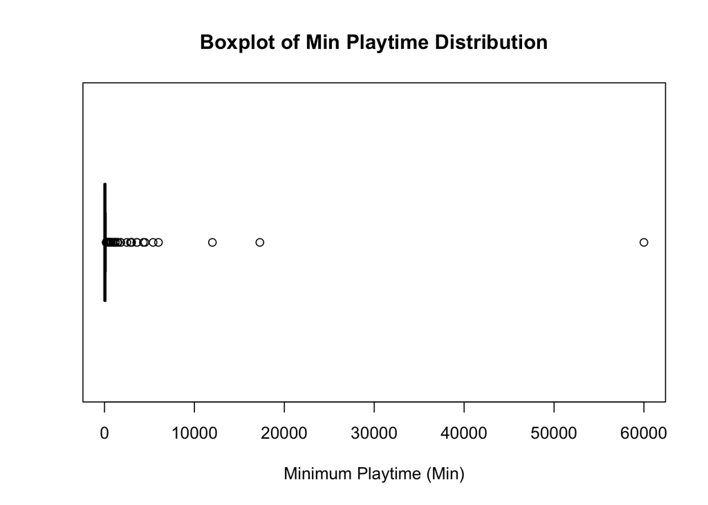

```r
#Then I made a boxplot of the minimum play times to visualize the distribution
boxplot(BoardGames_V1$min_playtime, horizontal = T, xlab = "Minimum Playtime (Min)", main = "Boxplot of Min Playtime Distribution")
```

As we can see, there are a few extreme outliers; which is making it hard to visualize the data; I’m going to remove those points temporarily.

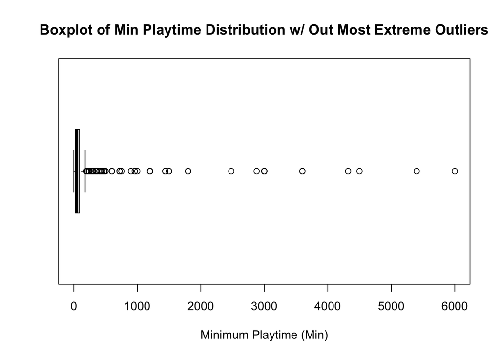

```r
# I'm filtering out the highest 3 observations which were much higher than any of the other min play-times
BoardGames_V1.1 <- BoardGames_V1 %>%
  filter(min_playtime <= 6000)
boxplot(BoardGames_V1.1$min_playtime, horizontal = T, xlab = "Minimum Playtime (Min)", main = "Boxplot of Min Playtime Distribution w/ Out Most Extreme Outliers")
```

As we can see, this graph still isn’t great, with most of the data cramped at the low end and a few high values, however, at this point I’m still going to try to divide up the data into categories:

```r
# Here I am using case_when to create categories for the minimum playtime for each game, with +10-30 meaning more than 10, up to 30 minutes, etc.
BoardGames_V2 <- BoardGames_V1 %>%
  mutate(min_play_categories = case_when(
    min_playtime == 0 ~ "0:No Min Playtime",
    min_playtime > 0 & min_playtime <= 10 ~ "1:10 min or less",
    min_playtime > 10 & min_playtime <= 30 ~ "2:+10-30 min",
    min_playtime > 30 & min_playtime <= 60 ~ "3:+30-60 min",
    min_playtime > 60 & min_playtime <= 180 ~ "4:+1-3 hrs",
    min_playtime > 180 & min_playtime <= 720 ~ "5:+3-12 hrs",
    min_playtime > 720 ~ "6:More than 12 hrs"
  )
)
BoardGames_V2 <- BoardGames_V2 %>%
  relocate(min_play_categories, .after = min_playtime)
head(BoardGames_V2)
```

|  | min_age | min_playtime | min_play_categories | average_rating | game_id | description | image | max_players | max_playtime | min_players | name | playing_time | thumbnail | year_published | artist | category | compilation | designer | expansion | family | mechanic | publisher | users_rated |
| --- | --- | --- | --- | --- | --- | --- | --- | --- | --- | --- | --- | --- | --- | --- | --- | --- | --- | --- | --- | --- | --- | --- | --- |
| 1 | 14 | 240 | 5:+3-12 hrs | 7.66508 | 1 | Die Macher is a game about seven sequential political races in different regions of Germany. Players are in charge of national political parties, and must manage limited resources to help their party … | //cf.geekdo-images.com/images/pic159509.jpg | 5 | 240 | 3 | Die Macher | 240 | //cf.geekdo-images.com/images/pic159509_t.jpg | 1986 | Marcus Gschwendtner | Economic,Negotiation,Political | NA | Karl-Heinz Schmiel | NA | Country: Germany,Valley Games Classic Line | Area Control / Area Influence,Auction/Bidding,Dice Rolling,Hand Management,Simultaneous Action Selection | Hans im Glück Verlags-GmbH,Moskito Spiele,Valley Games, Inc. | 4498 |
| 2 | 12 | 30 | 2:+10-30 min | 6.60815 | 2 | Dragonmaster is a trick-taking card game based on an older game called Coup d'etat. Each player is given a supply of plastic gems, which represent points. Each player will get to be the dealer for fiv… | //cf.geekdo-images.com/images/pic184174.jpg | 4 | 30 | 3 | Dragonmaster | 30 | //cf.geekdo-images.com/images/pic184174_t.jpg | 1981 | Bob Pepper | Card Game,Fantasy | NA | G. W. "Jerry" D'Arcey | NA | Animals: Dragons | Trick-taking | E.S. Lowe,Milton Bradley | 478 |
| 3 | 10 | 30 | 2:+10-30 min | 7.44119 | 3 | Part of the Knizia tile-laying trilogy, Samurai is set in medieval Japan. Players compete to gain the favor of three factions: samurai, peasants, and priests, which are represented by helmet, rice pad… | //cf.geekdo-images.com/images/pic3211873.jpg | 4 | 60 | 2 | Samurai | 60 | //cf.geekdo-images.com/images/pic3211873_t.jpg | 1998 | Franz Vohwinkel | Abstract Strategy,Medieval | NA | Reiner Knizia | NA | Asian Theme,Country: Japan,Knizia tile-laying trilogy,Samurai | Area Control / Area Influence,Hand Management,Set Collection,Tile Placement | 999 Games,ABACUSSPIELE,Astrel Games,Ceilikan Jogos,Descartes Editeur,Edge Entertainment,Fantasy Flight Games,Galakta,Hans im Glück Verlags-GmbH,Hobby Japan,Lacerta,Lautapelit.fi,Rio Grande Games,Skand… | 12019 |
| 4 | 12 | 60 | 3:+30-60 min | 6.60675 | 4 | When you see the triangular box and the luxurious, large blocks, you can tell this game was designed to be beautiful as well as functional. The object of the game is to build pyramids out of the diffe… | //cf.geekdo-images.com/images/pic285299.jpg | 4 | 60 | 2 | Tal der Könige | 60 | //cf.geekdo-images.com/images/pic285299_t.jpg | 1992 | NA | Ancient | NA | Christian Beierer | NA | Country: Egypt,Promotional Board Games | Action Point Allowance System,Area Control / Area Influence,Auction/Bidding,Set Collection | KOSMOS | 314 |
| 5 | 12 | 90 | 4:+1-3 hrs | 7.35830 | 5 | In Acquire, each player strategically invests in businesses, trying to retain a majority of stock. As the businesses grow with tile placements, they also start merging, giving the majority stockholder… | //cf.geekdo-images.com/images/pic342163.jpg | 6 | 90 | 3 | Acquire | 90 | //cf.geekdo-images.com/images/pic342163_t.jpg | 1964 | Scott Okumura,Peter Whitley | Economic | NA | Sid Sackson | NA | 3M Bookshelf Series | Hand Management,Stock Holding,Tile Placement | 3M,Avalon Hill,Avalon Hill (Hasbro),Dujardin,Grow Jogos e Brinquedos,PS-Games,Schmidt France,Schmidt International,Schmidt Spiele,Selecta Spel en Hobby,Smart Games, Inc. | 15195 |
| 6 | 12 | 240 | 5:+3-12 hrs | 6.52534 | 6 | In the ancient lands along the Mediterranean, players attempt to satisfy their unique victory conditions via trade, war and construction. This lavishly produced game contains tons of wooden game compo… | //cf.geekdo-images.com/images/pic28424.jpg | 6 | 240 | 2 | Mare Mediterraneum | 240 | //cf.geekdo-images.com/images/pic28424_t.jpg | 1989 | Jean du Poël | Civilization,Nautical | NA | Jean du Poël | NA | Cities: Marseille | Dice Rolling | Historien Spiele Galerie (Historien Spielegalerie) | 73 |

```r
#Similar to above, I want to look at my age data, and see what the distribution is so that I can find good cut points for my categorization. First I used the count function to see the distribution of observations for each age.
BoardGames_V2 %>%
  count(min_age)
```

| min_age | n |
| --- | --- |
| 0 | 588 |
| 2 | 3 |
| 3 | 47 |
| 4 | 101 |
| 5 | 188 |
| 6 | 391 |
| 7 | 351 |
| 8 | 2062 |
| 9 | 210 |
| 10 | 2196 |

[output cut: 12 more lines]

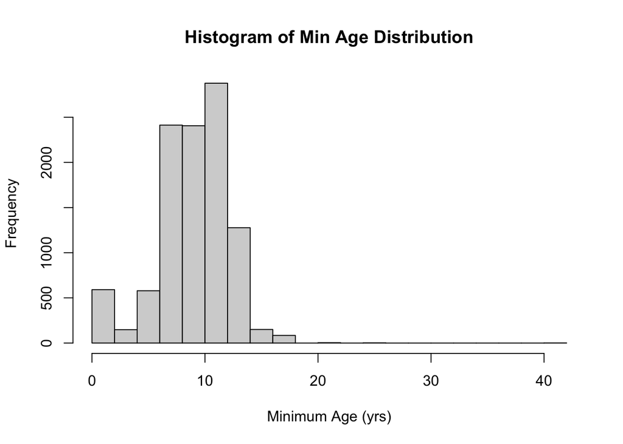

```r
#Then I made a rough histogram to visualize the distribution
hist(BoardGames_V2$min_age, xlab = "Minimum Age (yrs)", ylab = "Frequency", main = "Histogram of Min Age Distribution")
```

Based on the information from my exploratory analysis of the minimum age distribution, and my own knowledge of children, I have chosen to cut the age distribution into the following categories: No Min Age, Young Child (1-6 yrs), Older Child (7-12 yrs), Teen (13-17 yrs), and Adult (18+ yrs)

```r
# Here I am using case_when to create categories for the minimum age of player for each game
BoardGames_V3 <- BoardGames_V2 %>%
  mutate(min_age_categories = case_when(
    min_age == 0 ~ "0:No Min Age",
    min_age > 0 & min_age <= 6 ~ "1:Young Child (0-6 yrs)",
    min_age > 6 & min_age <= 12 ~ "2:Older Child (7-12 yrs)",
    min_age > 12 & min_age <= 17 ~ "3:Teen (13-17 yrs)",
    min_age > 17 ~ "4:Adult (18+ yrs)"
  )
)
BoardGames_V3 <- BoardGames_V3 %>%
  relocate(min_age_categories, .after = min_age)
```

> *Show your transformed table here.* Use tools such as `glimpse()`, `skim()` or `head()` to illustrate your point.

Now, we can see that our rearrangement and re-categorization worked:

```r
head(BoardGames_V3)
```

|  | min_age | min_age_categories | min_playtime | min_play_categories | average_rating | game_id | description | image | max_players | max_playtime | min_players | name | playing_time | thumbnail | year_published | artist | category | compilation | designer | expansion | family | mechanic | publisher | users_rated |
| --- | --- | --- | --- | --- | --- | --- | --- | --- | --- | --- | --- | --- | --- | --- | --- | --- | --- | --- | --- | --- | --- | --- | --- | --- |
| 1 | 14 | 3:Teen (13-17 yrs) | 240 | 5:+3-12 hrs | 7.66508 | 1 | Die Macher is a game about seven sequential political races in different regions of Germany. Players are in charge of national political parties, and must manage limited resources to help their party … | //cf.geekdo-images.com/images/pic159509.jpg | 5 | 240 | 3 | Die Macher | 240 | //cf.geekdo-images.com/images/pic159509_t.jpg | 1986 | Marcus Gschwendtner | Economic,Negotiation,Political | NA | Karl-Heinz Schmiel | NA | Country: Germany,Valley Games Classic Line | Area Control / Area Influence,Auction/Bidding,Dice Rolling,Hand Management,Simultaneous Action Selection | Hans im Glück Verlags-GmbH,Moskito Spiele,Valley Games, Inc. | 4498 |
| 2 | 12 | 2:Older Child (7-12 yrs) | 30 | 2:+10-30 min | 6.60815 | 2 | Dragonmaster is a trick-taking card game based on an older game called Coup d'etat. Each player is given a supply of plastic gems, which represent points. Each player will get to be the dealer for fiv… | //cf.geekdo-images.com/images/pic184174.jpg | 4 | 30 | 3 | Dragonmaster | 30 | //cf.geekdo-images.com/images/pic184174_t.jpg | 1981 | Bob Pepper | Card Game,Fantasy | NA | G. W. "Jerry" D'Arcey | NA | Animals: Dragons | Trick-taking | E.S. Lowe,Milton Bradley | 478 |
| 3 | 10 | 2:Older Child (7-12 yrs) | 30 | 2:+10-30 min | 7.44119 | 3 | Part of the Knizia tile-laying trilogy, Samurai is set in medieval Japan. Players compete to gain the favor of three factions: samurai, peasants, and priests, which are represented by helmet, rice pad… | //cf.geekdo-images.com/images/pic3211873.jpg | 4 | 60 | 2 | Samurai | 60 | //cf.geekdo-images.com/images/pic3211873_t.jpg | 1998 | Franz Vohwinkel | Abstract Strategy,Medieval | NA | Reiner Knizia | NA | Asian Theme,Country: Japan,Knizia tile-laying trilogy,Samurai | Area Control / Area Influence,Hand Management,Set Collection,Tile Placement | 999 Games,ABACUSSPIELE,Astrel Games,Ceilikan Jogos,Descartes Editeur,Edge Entertainment,Fantasy Flight Games,Galakta,Hans im Glück Verlags-GmbH,Hobby Japan,Lacerta,Lautapelit.fi,Rio Grande Games,Skand… | 12019 |
| 4 | 12 | 2:Older Child (7-12 yrs) | 60 | 3:+30-60 min | 6.60675 | 4 | When you see the triangular box and the luxurious, large blocks, you can tell this game was designed to be beautiful as well as functional. The object of the game is to build pyramids out of the diffe… | //cf.geekdo-images.com/images/pic285299.jpg | 4 | 60 | 2 | Tal der Könige | 60 | //cf.geekdo-images.com/images/pic285299_t.jpg | 1992 | NA | Ancient | NA | Christian Beierer | NA | Country: Egypt,Promotional Board Games | Action Point Allowance System,Area Control / Area Influence,Auction/Bidding,Set Collection | KOSMOS | 314 |
| 5 | 12 | 2:Older Child (7-12 yrs) | 90 | 4:+1-3 hrs | 7.35830 | 5 | In Acquire, each player strategically invests in businesses, trying to retain a majority of stock. As the businesses grow with tile placements, they also start merging, giving the majority stockholder… | //cf.geekdo-images.com/images/pic342163.jpg | 6 | 90 | 3 | Acquire | 90 | //cf.geekdo-images.com/images/pic342163_t.jpg | 1964 | Scott Okumura,Peter Whitley | Economic | NA | Sid Sackson | NA | 3M Bookshelf Series | Hand Management,Stock Holding,Tile Placement | 3M,Avalon Hill,Avalon Hill (Hasbro),Dujardin,Grow Jogos e Brinquedos,PS-Games,Schmidt France,Schmidt International,Schmidt Spiele,Selecta Spel en Hobby,Smart Games, Inc. | 15195 |
| 6 | 12 | 2:Older Child (7-12 yrs) | 240 | 5:+3-12 hrs | 6.52534 | 6 | In the ancient lands along the Mediterranean, players attempt to satisfy their unique victory conditions via trade, war and construction. This lavishly produced game contains tons of wooden game compo… | //cf.geekdo-images.com/images/pic28424.jpg | 6 | 240 | 2 | Mare Mediterraneum | 240 | //cf.geekdo-images.com/images/pic28424_t.jpg | 1989 | Jean du Poël | Civilization,Nautical | NA | Jean du Poël | NA | Cities: Marseille | Dice Rolling | Historien Spiele Galerie (Historien Spielegalerie) | 73 |

I can also make separate tables for each of the different age groups, if needed for subsetting analysis later:

```r
#Again, this code came from Dr. Minnier and Dr. Niederhausen's "An Introduction to R and RStudio for Exploratory Data Analysis" Part 2 slides. https://jminnier-berd-r-courses.netlify.app/01-intro-r-eda/01_intro_r_eda_part2#1, as mentioned above for the relocation data

NoMinAge_Games <- BoardGames_V3 %>%
  filter(min_age_categories == "0:No Min Age")
head(NoMinAge_Games)
```

|  | min_age | min_age_categories | min_playtime | min_play_categories | average_rating | game_id | description | image | max_players | max_playtime | min_players | name | playing_time | thumbnail | year_published | artist | category | compilation | designer | expansion | family | mechanic | publisher | users_rated |
| --- | --- | --- | --- | --- | --- | --- | --- | --- | --- | --- | --- | --- | --- | --- | --- | --- | --- | --- | --- | --- | --- | --- | --- | --- |
| 1 | 0 | 0:No Min Age | 120 | 4:+1-3 hrs | 5.70588 | 166 | In this cheerfully demented offering, participants each play the part of a disease trying to inflict misery on the European populace. Each disease has mortality (lethalness) and virulence (contagiousn… | //cf.geekdo-images.com/images/pic180585.jpg | 6 | 120 | 2 | Black Death | 120 | //cf.geekdo-images.com/images/pic180585_t.jpg | 1993 | Darrell Midgette | Educational,Medical | NA | Greg Porter | NA | NA | Action Point Allowance System,Dice Rolling,Point to Point Movement,Simulation,Variable Player Powers | BTRC (Blacksburg Tactical Research Center),Devir,Sphinx Spieleverlag | 119 |
| 2 | 0 | 0:No Min Age | 300 | 5:+3-12 hrs | 7.25508 | 288 | Rossyia 1917 is mid-high complexity game of the Russian Civil War in 1917 . It covers the military aspect of the civil war at an operational level. Units are brigades and divisions, rated for steps, c… | //cf.geekdo-images.com/images/pic49238.jpg | 5 | 300 | 2 | Rossyïa 1917 | 300 | //cf.geekdo-images.com/images/pic49238_t.jpg | 1995 | NA | Civil War,Wargame | NA | François-Stanislas Thomas | NA | NA | Hex-and-Counter | Azure Wish Enterprise (AWE) | 63 |
| 3 | 0 | 0:No Min Age | 90 | 4:+1-3 hrs | 6.21793 | 563 | The game of the great American lawsuit. &#10;In this fast-paced card game, each player becomes a lawyer, who weighs the facts of the case, examines the law, watches out for hostile juries, and even oc… | //cf.geekdo-images.com/images/pic3923.jpg | 15 | 90 | 4 | Doolittle & Waite | 90 | //cf.geekdo-images.com/images/pic3923_t.jpg | 1986 | NA | Bluffing,Card Game,Negotiation | NA | (Uncredited) | NA | NA | Auction/Bidding | Inward Games | 87 |
| 4 | 0 | 0:No Min Age | 0 | 0:No Min Playtime | 6.15255 | 642 | Oodles is made up of three main items... a nifty ticking electronic timer that stops when you hold the button down and starts up again when you let go of it, an extraneous plastic Oodle stick (a large… | //cf.geekdo-images.com/images/pic2493652.jpg | 10 | 0 | 3 | Oodles | 0 | //cf.geekdo-images.com/images/pic2493652_t.jpg | 1992 | NA | Party Game,Trivia | NA | Brian Hersch | NA | NA | NA | Milton Bradley | 232 |
| 5 | 0 | 0:No Min Age | 30 | 2:+10-30 min | 6.12509 | 669 | A light card game involving the build-up and destruction of medieval towns. In the Prosperity phase players attempt to build up their populations via stealing from other players or via improvements. T… | //cf.geekdo-images.com/images/pic5254.jpg | 6 | 30 | 2 | Plague & Pestilence | 30 | //cf.geekdo-images.com/images/pic5254_t.jpg | 1993 | Paul Dale | Card Game,Medieval | NA | Tray Green,Dawn Payn | NA | NA | Card Drafting,Dice Rolling,Take That | Chessex,Hillary's Toy Box | 627 |
| 6 | 0 | 0:No Min Age | 30 | 2:+10-30 min | 6.33246 | 695 | This abstract strategy doesn't really use the Fibonacci sequence (1,1,2,3,5,8,13...), but it's pretty cool nonetheless. The first player starts off with one move, the second player takes two, first pl… | //cf.geekdo-images.com/images/pic1007.jpg | 2 | 30 | 2 | Fibonacci | 30 | //cf.geekdo-images.com/images/pic1007_t.jpg | 1992 | NA | Abstract Strategy | NA | Thomas Naylor | NA | NA | NA | Thomas Naylor and Associates | 57 |

```r
YoungChild_BoardGames <- BoardGames_V3 %>%
  filter(min_age_categories == "1:Young Child (0-6 yrs)")
head(YoungChild_BoardGames)
```

|  | min_age | min_age_categories | min_playtime | min_play_categories | average_rating | game_id | description | image | max_players | max_playtime | min_players | name | playing_time | thumbnail | year_published | artist | category | compilation | designer | expansion | family | mechanic | publisher | users_rated |
| --- | --- | --- | --- | --- | --- | --- | --- | --- | --- | --- | --- | --- | --- | --- | --- | --- | --- | --- | --- | --- | --- | --- | --- | --- |
| 1 | 6 | 1:Young Child (0-6 yrs) | 30 | 2:+10-30 min | 7.24935 | 150 | This game entry refers to two nearly identical games which are not compatible with one another. Ages 6 and up.&#10;&#10;PitchCar and Carabande are dexterity games where large, wooden, puzzle-like piec… | //cf.geekdo-images.com/images/pic215555.jpg | 8 | 30 | 2 | PitchCar | 30 | //cf.geekdo-images.com/images/pic215555_t.jpg | 1995 | Jean du Poël | Action / Dexterity,Children's Game,Party Game,Racing,Sports | NA | Jean du Poël | PitchCar Extension,PitchCar Extension 2,PitchCar Extension 5: The Cross,PitchCar Extension 6,PitchCar Special Long Straights,PitchCar: Stunt Race | Finger Flicking Games,PitchCar,Promotional Board Games,Sports: Auto Racing | Modular Board | Ferti,Goldsieber Spiele,Historien Spiele Galerie (Historien Spielegalerie),Lautapelit.fi,Vision | 7562 |
| 2 | 6 | 1:Young Child (0-6 yrs) | 30 | 2:+10-30 min | 6.40881 | 293 | This is definitely one of the more unusual offerings from our German friends. An assortment of oddly shaped wooden blocks are placed onto a round, wooden 'platter.' The platter has a cork ball on its … | //cf.geekdo-images.com/images/pic665201.jpg | 7 | 30 | 2 | Bamboleo | 30 | //cf.geekdo-images.com/images/pic665201_t.jpg | 1996 | Oliver Richtberg,Jacques Zeimet | Action / Dexterity,Party Game | NA | Jacques Zeimet | Waagemut | NA | Press Your Luck | Competo / Marektoy,Kaissa Chess & Games,Rio Grande Games,Swan Panasia Co., Ltd.,Vennerød Forlag AS,Zoch Verlag | 1170 |
| 3 | 4 | 1:Young Child (0-6 yrs) | 10 | 1:10 min or less | 6.88984 | 327 | In Loopin' Louie, a battery-powered motor placed in the center of the table rotates a boom with a little plastic plane. Four radial arms lead out to the players' barns and the chickens they're trying … | //cf.geekdo-images.com/images/pic289639.jpg | 4 | 10 | 2 | Loopin' Louie | 10 | //cf.geekdo-images.com/images/pic289639_t.jpg | 1992 | NA | Action / Dexterity,Animals,Aviation / Flight,Children's Game,Electronic,Movies / TV / Radio theme,Real-time | NA | Masaru Aoki,Carol Wiseley | NA | Animals: Chickens,Celebrities: Walt Disney,Toy Story | Player Elimination | Bandai,Broadway Toys LTD,The Canadian Group,Crown Products,Editrice Giochi,Goliath B.V.,Hanayama,Hasbro,Ideal,K.E. Mathiasen A/S,Kod Kod,Korea Boardgames co., Ltd.,Longshore Limited,MB Giochi,MB Jeux,… | 6617 |
| 4 | 6 | 1:Young Child (0-6 yrs) | 15 | 2:+10-30 min | 6.64011 | 337 | In Circus Flohcati, players try to complete sets of cards before the game ends. A player begins her turn with several face-up cards to choose from. If she doesn&rsquo;t like them, she can draw another… | //cf.geekdo-images.com/images/pic3521285.jpg | 5 | 15 | 2 | Circus Flohcati | 15 | //cf.geekdo-images.com/images/pic3521285_t.jpg | 1998 | Franz Vohwinkel,Heiko Günther,Yusuke Mamada | Card Game | NA | Reiner Knizia | NA | Animals: Fleas,Circus,Crowdfunding: Kickstarter,The Mike Line | Card Drafting,Press Your Luck,Set Collection | ABACUSSPIELE,AMIGO Spiel + Freizeit GmbH,Gameology, Inc. (게임올로지),Grail Games,New Games Order, LLC,Play Smart,Ravensburger Spieleverlag GmbH,Rio Grande Games,TwoPlus Games,University Games | 1946 |
| 5 | 6 | 1:Young Child (0-6 yrs) | 30 | 2:+10-30 min | 5.71878 | 485 | Galloping Pigs is a cute little 'not-quite-a-children's-game' game where players are collecting points in the form of food. Plastic pigs are placed on a track made from cards laid in a circle, and the… | //cf.geekdo-images.com/images/pic10338.jpg | 5 | 30 | 2 | Galloping Pigs | 30 | //cf.geekdo-images.com/images/pic10338_t.jpg | 1992 | Iskender Gider,Franz Vohwinkel | Animals,Card Game,Children's Game | NA | Heinz Meister | NA | Animals: Pigs | NA | ABACUSSPIELE,HomoLudicus,Oya,PS-Games,Ravensburger Spieleverlag GmbH,Red Glove,Rio Grande Games,Swan Panasia Co., Ltd. | 863 |
| 6 | 4 | 1:Young Child (0-6 yrs) | 15 | 2:+10-30 min | 5.78521 | 486 | In Barnyard Buddies, a bunch of cards depicting various animals in different colors are placed faceup on the table. Each turn, one player reveals a card that depicts four animals, each in a different … | //cf.geekdo-images.com/images/pic738245.jpg | 8 | 15 | 2 | Barnyard Buddies | 15 | //cf.geekdo-images.com/images/pic738245_t.jpg | 1996 | Guy Francis,Oliver Freudenreich,Uschi Heusel | Animals,Children's Game,Real-time | NA | Reinhard Staupe | NA | Circus | Pattern Recognition | 999 Games,AMIGO Spiel + Freizeit GmbH,Asmodee,Gamewright,Gigamic,Kaissa Chess & Games,Playroom Entertainment,Rio Grande Games | 186 |

```r
OlderChild_BoardGames <- BoardGames_V3 %>%
  filter(min_age_categories == "2:Older Child (7-12 yrs)")
head(OlderChild_BoardGames)
```

|  | min_age | min_age_categories | min_playtime | min_play_categories | average_rating | game_id | description | image | max_players | max_playtime | min_players | name | playing_time | thumbnail | year_published | artist | category | compilation | designer | expansion | family | mechanic | publisher | users_rated |
| --- | --- | --- | --- | --- | --- | --- | --- | --- | --- | --- | --- | --- | --- | --- | --- | --- | --- | --- | --- | --- | --- | --- | --- | --- |
| 1 | 12 | 2:Older Child (7-12 yrs) | 30 | 2:+10-30 min | 6.60815 | 2 | Dragonmaster is a trick-taking card game based on an older game called Coup d'etat. Each player is given a supply of plastic gems, which represent points. Each player will get to be the dealer for fiv… | //cf.geekdo-images.com/images/pic184174.jpg | 4 | 30 | 3 | Dragonmaster | 30 | //cf.geekdo-images.com/images/pic184174_t.jpg | 1981 | Bob Pepper | Card Game,Fantasy | NA | G. W. "Jerry" D'Arcey | NA | Animals: Dragons | Trick-taking | E.S. Lowe,Milton Bradley | 478 |
| 2 | 10 | 2:Older Child (7-12 yrs) | 30 | 2:+10-30 min | 7.44119 | 3 | Part of the Knizia tile-laying trilogy, Samurai is set in medieval Japan. Players compete to gain the favor of three factions: samurai, peasants, and priests, which are represented by helmet, rice pad… | //cf.geekdo-images.com/images/pic3211873.jpg | 4 | 60 | 2 | Samurai | 60 | //cf.geekdo-images.com/images/pic3211873_t.jpg | 1998 | Franz Vohwinkel | Abstract Strategy,Medieval | NA | Reiner Knizia | NA | Asian Theme,Country: Japan,Knizia tile-laying trilogy,Samurai | Area Control / Area Influence,Hand Management,Set Collection,Tile Placement | 999 Games,ABACUSSPIELE,Astrel Games,Ceilikan Jogos,Descartes Editeur,Edge Entertainment,Fantasy Flight Games,Galakta,Hans im Glück Verlags-GmbH,Hobby Japan,Lacerta,Lautapelit.fi,Rio Grande Games,Skand… | 12019 |
| 3 | 12 | 2:Older Child (7-12 yrs) | 60 | 3:+30-60 min | 6.60675 | 4 | When you see the triangular box and the luxurious, large blocks, you can tell this game was designed to be beautiful as well as functional. The object of the game is to build pyramids out of the diffe… | //cf.geekdo-images.com/images/pic285299.jpg | 4 | 60 | 2 | Tal der Könige | 60 | //cf.geekdo-images.com/images/pic285299_t.jpg | 1992 | NA | Ancient | NA | Christian Beierer | NA | Country: Egypt,Promotional Board Games | Action Point Allowance System,Area Control / Area Influence,Auction/Bidding,Set Collection | KOSMOS | 314 |
| 4 | 12 | 2:Older Child (7-12 yrs) | 90 | 4:+1-3 hrs | 7.35830 | 5 | In Acquire, each player strategically invests in businesses, trying to retain a majority of stock. As the businesses grow with tile placements, they also start merging, giving the majority stockholder… | //cf.geekdo-images.com/images/pic342163.jpg | 6 | 90 | 3 | Acquire | 90 | //cf.geekdo-images.com/images/pic342163_t.jpg | 1964 | Scott Okumura,Peter Whitley | Economic | NA | Sid Sackson | NA | 3M Bookshelf Series | Hand Management,Stock Holding,Tile Placement | 3M,Avalon Hill,Avalon Hill (Hasbro),Dujardin,Grow Jogos e Brinquedos,PS-Games,Schmidt France,Schmidt International,Schmidt Spiele,Selecta Spel en Hobby,Smart Games, Inc. | 15195 |
| 5 | 12 | 2:Older Child (7-12 yrs) | 240 | 5:+3-12 hrs | 6.52534 | 6 | In the ancient lands along the Mediterranean, players attempt to satisfy their unique victory conditions via trade, war and construction. This lavishly produced game contains tons of wooden game compo… | //cf.geekdo-images.com/images/pic28424.jpg | 6 | 240 | 2 | Mare Mediterraneum | 240 | //cf.geekdo-images.com/images/pic28424_t.jpg | 1989 | Jean du Poël | Civilization,Nautical | NA | Jean du Poël | NA | Cities: Marseille | Dice Rolling | Historien Spiele Galerie (Historien Spielegalerie) | 73 |
| 6 | 8 | 2:Older Child (7-12 yrs) | 20 | 2:+10-30 min | 6.50534 | 7 | In Cathedral, each player has a set of pieces of a different color. The pieces are in the shapes of buildings, covering from one to five square units. The first player takes the single neutral Cathedr… | //cf.geekdo-images.com/images/pic181642.jpg | 2 | 20 | 2 | Cathedral | 20 | //cf.geekdo-images.com/images/pic181642_t.jpg | 1978 | S. Mattusek | Abstract Strategy | NA | Robert P. Moore | NA | Combinatorial,Polyominoes | Area Enclosure,Pattern Building,Pattern Recognition,Tile Placement | Brightway Products Ltd,Falomir Juegos,Family Games, Inc.,Gazebo Games UK Ltd.,Gigamic,Holzinsel,Lagoon Games,Mattel,Robert P. Moore Games,Yangxin Industrial Company Limited | 2751 |

```r
Teen_BoardGames <- BoardGames_V3 %>%
  filter(min_age_categories == "3:Teen (13-17 yrs)")
head(Teen_BoardGames)
```

|  | min_age | min_age_categories | min_playtime | min_play_categories | average_rating | game_id | description | image | max_players | max_playtime | min_players | name | playing_time | thumbnail | year_published | artist | category | compilation | designer | expansion | family | mechanic | publisher | users_rated |
| --- | --- | --- | --- | --- | --- | --- | --- | --- | --- | --- | --- | --- | --- | --- | --- | --- | --- | --- | --- | --- | --- | --- | --- | --- |
| 1 | 14 | 3:Teen (13-17 yrs) | 240 | 5:+3-12 hrs | 7.66508 | 1 | Die Macher is a game about seven sequential political races in different regions of Germany. Players are in charge of national political parties, and must manage limited resources to help their party … | //cf.geekdo-images.com/images/pic159509.jpg | 5 | 240 | 3 | Die Macher | 240 | //cf.geekdo-images.com/images/pic159509_t.jpg | 1986 | Marcus Gschwendtner | Economic,Negotiation,Political | NA | Karl-Heinz Schmiel | NA | Country: Germany,Valley Games Classic Line | Area Control / Area Influence,Auction/Bidding,Dice Rolling,Hand Management,Simultaneous Action Selection | Hans im Glück Verlags-GmbH,Moskito Spiele,Valley Games, Inc. | 4498 |
| 2 | 13 | 3:Teen (13-17 yrs) | 90 | 4:+1-3 hrs | 6.51776 | 9 | Although referred to as a sequel to El Grande, El Caballero shares few aspects with its namesake, being a fun but intense brain-burner in which players explore and attempt to control the lands and wat… | //cf.geekdo-images.com/images/pic1731731.jpg | 4 | 90 | 2 | El Caballero | 90 | //cf.geekdo-images.com/images/pic1731731_t.jpg | 1998 | Doris Matthäus | Exploration | NA | Wolfgang Kramer,Richard Ulrich | NA | El Grande | Area Control / Area Influence,Tile Placement | 999 Games,Hans im Glück Verlags-GmbH,Rio Grande Games | 1263 |
| 3 | 13 | 3:Teen (13-17 yrs) | 45 | 3:+30-60 min | 7.06751 | 11 | Bohnanza is the first in the Bohnanza family of games and has been published in several different editions.&#10;&#10;The cards are colorful depictions of beans in various descriptive poses, and the ob… | //cf.geekdo-images.com/images/pic69366.jpg | 7 | 45 | 2 | Bohnanza | 45 | //cf.geekdo-images.com/images/pic69366_t.jpg | 1997 | Fréderic Bertrand,Marek Bláha,Andrea Boekhoff,Klemens Franz,Oliver Freudenreich,Inge George,Guido Hoffmann,Alexander Jung,Harald Lieske,Atelier Löwentor,Doris Matthäus,Björn Pertoft,Uwe Rosenberg,Joha… | Card Game,Farming,Negotiation | NA | Uwe Rosenberg | Auf der schwäb'schen Eisenbohn,Bohn Camillo,Bohnanza Erweiterungs-Set,Bohnanza Erweiterungs-Set (Revised Edition),Bohnanza: Amigo Bohnentaler,Bohnanza: Bean Market,Bohnanza: Bohnaparte & High Bohn,Boh… | Bohnanza,Lookout Bean Games | Hand Management,Set Collection,Trading | AMIGO Spiel + Freizeit GmbH,999 Games,Brain Games,Copag - Cia. Paulista de Artes Gráficas,Corfix,G3,Gigamic,Kaissa Chess & Games,Kikigagne?,Korea Boardgames co., Ltd.,Lautapelit.fi,Lifestyle Boardgame… | 28354 |
| 4 | 14 | 3:Teen (13-17 yrs) | 300 | 5:+3-12 hrs | 6.08468 | 52 | Mighty Empires is both a strategic layer to the Warhammer system and a boardgame in its own right. It allows players of the miniature game to manage a kingdom, explore the world, and attempt to conque… | //cf.geekdo-images.com/images/pic994386.jpg | 3 | 300 | 2 | Mighty Empires | 300 | //cf.geekdo-images.com/images/pic994386_t.jpg | 1990 | Tony Ackland,Albrecht Altdorfer,Dave Andrews,Chris Baker,Paul Bonner,Colin Howard,Martin McKenna,Russ Nicholson,John Sibbick,Stephen Tappin,Kevin Walker | Fantasy,Territory Building,Wargame | NA | Rick Priestley,Nigel Stillman | NA | Warhammer Fantasy Wargames | NA | Games Workshop Ltd. | 449 |
| 5 | 13 | 3:Teen (13-17 yrs) | 90 | 4:+1-3 hrs | 7.34313 | 54 | Tikal is a game of exploration within the Central American jungles in search of lost temples and the treasures within. Players send their team of explorers into the jungle, exposing more and more of t… | //cf.geekdo-images.com/images/pic178078.jpg | 4 | 90 | 2 | Tikal | 90 | //cf.geekdo-images.com/images/pic178078_t.jpg | 1999 | Mariusz Gandzel,Franz Vohwinkel | Exploration,Territory Building | NA | Michael Kiesling,Wolfgang Kramer | Jungle Zombie | Archaeology,Country: Guatemala,The Mask Trilogy,Promotional Board Games,Tropical theme | Action Point Allowance System,Area Control / Area Influence,Auction/Bidding,Grid Movement,Set Collection,Tile Placement | Ravensburger Spieleverlag GmbH,Rio Grande Games,dV Giochi,Egmont Polska,Gém Klub Kft.,Kellogg's,Maldito Games,Super Meeple | 13674 |
| 6 | 13 | 3:Teen (13-17 yrs) | 180 | 4:+1-3 hrs | 6.66780 | 57 | Schoko &amp; Co is all about producing chocolate in order to make money. Players are chocolate barons who have to contend with every element of the business from production to sales. Buy cocoa, conver… | //cf.geekdo-images.com/images/pic1378439.jpg | 4 | 180 | 2 | Schoko & Co. | 180 | //cf.geekdo-images.com/images/pic1378439_t.jpg | 1987 | (Uncredited) | Economic | NA | Yves Hirschfeld,Gilles Monnet | NA | NA | Auction/Bidding,Commodity Speculation | Schmidt Spiele | 371 |

```r
Adult_BoardGames <- BoardGames_V3 %>%
  filter(min_age_categories == "4:Adult (18+ yrs)")
head(Adult_BoardGames)
```

|  | min_age | min_age_categories | min_playtime | min_play_categories | average_rating | game_id | description | image | max_players | max_playtime | min_players | name | playing_time | thumbnail | year_published | artist | category | compilation | designer | expansion | family | mechanic | publisher | users_rated |
| --- | --- | --- | --- | --- | --- | --- | --- | --- | --- | --- | --- | --- | --- | --- | --- | --- | --- | --- | --- | --- | --- | --- | --- | --- |
| 1 | 18 | 4:Adult (18+ yrs) | 120 | 4:+1-3 hrs | 6.12852 | 133 | Each player in Frischfleish (Fresh Flesh) represents a unique group of individuals stranded on a desert island. Although there is a rescue attempt in the works, it's still a month away. In the meantim… | //cf.geekdo-images.com/images/pic464789.jpg | 6 | 120 | 2 | Frischfleisch | 120 | //cf.geekdo-images.com/images/pic464789_t.jpg | 1999 | Lars-Arne "Maura" Kalusky | Exploration,Horror | NA | Friedemann Friese | NA | NA | Modular Board | 2F-Spiele | 142 |
| 2 | 18 | 4:Adult (18+ yrs) | 60 | 3:+30-60 min | 5.93233 | 427 | Regarded as a distant cousin of the French card game, Mille Bornes, this card game casts the players as dope dealers looking to make a quick buck or two selling pot. Players seek to add 'drug deal' ca… | //cf.geekdo-images.com/images/pic264444.jpg | 6 | 60 | 2 | Grass | 60 | //cf.geekdo-images.com/images/pic264444_t.jpg | 1980 | NA | Card Game,Economic | NA | Jeff London | NA | NA | Hand Management,Take That | Euro Games | 970 |
| 3 | 18 | 4:Adult (18+ yrs) | 30 | 2:+10-30 min | 6.00105 | 514 | Players attempt to best anticipate how others perceive them. Each round consists of several private ballot votes on who best fits a particular question. Once votes are entered players guess at the num… | //cf.geekdo-images.com/images/pic116619.jpg | 6 | 30 | 3 | True Colors | 30 | //cf.geekdo-images.com/images/pic116619_t.jpg | 1989 | (Uncredited) | Deduction,Humor,Party Game | NA | Jean Tarrade | NA | NA | Betting/Wagering,Voting | Grand V,Jumbo,Milton Bradley,Piatnik,Pressman Toy Corp.,Tactic | 381 |
| 4 | 18 | 4:Adult (18+ yrs) | 60 | 3:+30-60 min | 6.17330 | 920 | Ultimate Ouburst is a superset of the original Outburst! featuring 2 extra rounds of play. ReverseBurst where you hear and answers and guess the topic and Challenge Outburst where you bid against the … | //cf.geekdo-images.com/images/pic243836.jpg | 0 | 60 | 0 | Ultimate Outburst | 60 | //cf.geekdo-images.com/images/pic243836_t.jpg | 1999 | NA | Party Game | NA | Brian Hersch | NA | Outburst | NA | Hasbro,Hersch and Company,Parker Brothers | 221 |
| 5 | 18 | 4:Adult (18+ yrs) | 60 | 3:+30-60 min | 4.60384 | 1748 | Scruples... The game that poses 252 moral dilemmas on issues of work, money, friends, family, neighbors and, of course relationships!&#10;&#10;User review: Each player is dealt five dilemma cards, eac… | //cf.geekdo-images.com/images/pic41470.jpg | 12 | 60 | 4 | A Question of Scruples | 60 | //cf.geekdo-images.com/images/pic41470_t.jpg | 1984 | NA | Bluffing,Party Game | NA | Henry Makow | NA | NA | Voting | Estrela,High Games Entertainment,Maruca Industries,MB Spiele,Milton Bradley,Parker Brothers | 612 |
| 6 | 18 | 4:Adult (18+ yrs) | 30 | 2:+10-30 min | 6.42352 | 1835 | Players look at a cartoon drawing with lots of details. A die is rolled, and half of the picture is obscured. Players must then write down as many things as they can find in the picture starting with … | //cf.geekdo-images.com/images/pic14612.jpg | 8 | 30 | 2 | Scrutineyes | 30 | //cf.geekdo-images.com/images/pic14612_t.jpg | 1992 | NA | Memory,Party Game | NA | Brian Hersch,Mike Wilks | NA | NA | NA | Hersch and Company,Mattel | 253 |

> *Are the values what you expected for the variables? Why or Why not?*

I was surprised that there were so many minimum playtime and minimum age values of zero; I honestly wasn’t sure if this was the equivalent of a “NA,” or if it was the game-designer’s indication that there was not a minimum playtime or not a minimum age limit. It order to account for this, I made a separate category for these games, so that I could choose whether or not to use them in my final analysis. Otherwise, I was not terribly surprised by anything so far.

## Visualizing and Summarizing the Data (15 points)

> *Use `group_by()/summarize()` to make a summary of the data here. The summary should be relevant to your research question*

First I will be addressing my primary research question, which was: how does the minimum playtime affect the average rating in the overall dataset?

**Main Question**

```r
#This summary is the average rating, grouped by minimum playtime
BoardGames_V3 %>%
  group_by(min_play_categories) %>%
  summarise(Number_Games = n(), Mean_Rating = mean(average_rating), Median_Rating = median(average_rating), Min_Rating = min(average_rating), Max_Rating = max(average_rating))
```

| min_play_categories | Number_Games | Mean_Rating | Median_Rating | Min_Rating | Max_Rating |
| --- | --- | --- | --- | --- | --- |
| 0:No Min Playtime | 300 | 6.259784 | 6.25284 | 1.84598 | 8.75802 |
| 1:10 min or less | 591 | 5.996373 | 6.06000 | 3.57980 | 8.49554 |
| 2:+10-30 min | 3879 | 6.197127 | 6.21929 | 1.96986 | 8.42502 |
| 3:+30-60 min | 3016 | 6.404907 | 6.42066 | 1.38421 | 9.00392 |
| 4:+1-3 hrs | 2087 | 6.595338 | 6.66196 | 3.46933 | 8.80263 |
| 5:+3-12 hrs | 628 | 6.887989 | 6.93888 | 3.76090 | 8.70848 |
| 6:More than 12 hrs | 31 | 7.421946 | 7.46138 | 5.62887 | 8.60210 |

Next I’ll look into my secondary question, which is: how does the min playtime affect mean rating when we stratify by age group?

**No Min Age**

```r
#No Min Age (possibly just NA category)
NoMinAge_Games %>%
  group_by(min_play_categories) %>%
  summarise(Number_Games = n(), Mean_Rating = mean(average_rating), Median_Rating = median(average_rating), Min_Rating = min(average_rating), Max_Rating = max(average_rating))
```

| min_play_categories | Number_Games | Mean_Rating | Median_Rating | Min_Rating | Max_Rating |
| --- | --- | --- | --- | --- | --- |
| 0:No Min Playtime | 89 | 6.891341 | 7.05789 | 4.28102 | 8.75802 |
| 1:10 min or less | 35 | 6.509503 | 6.41581 | 4.16146 | 8.49554 |
| 2:+10-30 min | 148 | 6.317421 | 6.29723 | 3.31857 | 8.26500 |
| 3:+30-60 min | 125 | 6.539054 | 6.57517 | 4.07851 | 8.27889 |
| 4:+1-3 hrs | 132 | 6.813608 | 6.93103 | 3.95738 | 8.45256 |
| 5:+3-12 hrs | 54 | 7.282165 | 7.33952 | 5.65250 | 8.07409 |
| 6:More than 12 hrs | 5 | 7.831270 | 7.99855 | 7.08621 | 8.13275 |

**Young Children**

```r
#Young Children
YoungChild_BoardGames %>%
  group_by(min_play_categories) %>%
  summarise(Number_Games = n(), Mean_Rating = mean(average_rating), Median_Rating = median(average_rating), Min_Rating = min(average_rating), Max_Rating = max(average_rating))
```

| min_play_categories | Number_Games | Mean_Rating | Median_Rating | Min_Rating | Max_Rating |
| --- | --- | --- | --- | --- | --- |
| 0:No Min Playtime | 19 | 5.754123 | 5.603920 | 4.54412 | 7.95660 |
| 1:10 min or less | 186 | 5.729157 | 5.831855 | 3.57980 | 8.32321 |
| 2:+10-30 min | 485 | 5.860332 | 5.982080 | 2.94593 | 7.54473 |
| 3:+30-60 min | 39 | 5.473696 | 5.449740 | 2.82928 | 7.25068 |
| 4:+1-3 hrs | 1 | 5.411730 | 5.411730 | 5.41173 | 5.41173 |

**Older Children**

```r
#Older Children
OlderChild_BoardGames %>%
  group_by(min_play_categories) %>%
  summarise(Number_Games = n(), Mean_Rating = mean(average_rating), Median_Rating = median(average_rating), Min_Rating = min(average_rating), Max_Rating = max(average_rating))
```

| min_play_categories | Number_Games | Mean_Rating | Median_Rating | Min_Rating | Max_Rating |
| --- | --- | --- | --- | --- | --- |
| 0:No Min Playtime | 163 | 6.058651 | 6.094500 | 2.07772 | 8.27531 |
| 1:10 min or less | 329 | 6.056633 | 6.091770 | 3.71719 | 7.93103 |
| 2:+10-30 min | 2827 | 6.207419 | 6.224180 | 1.96986 | 8.42502 |
| 3:+30-60 min | 2309 | 6.321979 | 6.352120 | 1.38421 | 9.00392 |
| 4:+1-3 hrs | 1582 | 6.480303 | 6.538645 | 3.46933 | 8.61189 |
| 5:+3-12 hrs | 468 | 6.790621 | 6.826615 | 3.86800 | 8.38678 |
| 6:More than 12 hrs | 18 | 7.302177 | 7.304475 | 6.34307 | 8.41941 |

**Teens**

```r
#Teens
Teen_BoardGames %>%
  group_by(min_play_categories) %>%
  summarise(Number_Games = n(), Mean_Rating = mean(average_rating), Median_Rating = median(average_rating), Min_Rating = min(average_rating), Max_Rating = max(average_rating))
```

| min_play_categories | Number_Games | Mean_Rating | Median_Rating | Min_Rating | Max_Rating |
| --- | --- | --- | --- | --- | --- |
| 0:No Min Playtime | 25 | 5.876603 | 5.69714 | 1.84598 | 8.07596 |
| 1:10 min or less | 38 | 6.339960 | 6.37521 | 3.86154 | 7.37269 |
| 2:+10-30 min | 393 | 6.526323 | 6.60498 | 2.33940 | 8.25085 |
| 3:+30-60 min | 511 | 6.848542 | 6.94405 | 3.96702 | 8.93184 |
| 4:+1-3 hrs | 364 | 7.026972 | 7.09337 | 3.94300 | 8.80263 |
| 5:+3-12 hrs | 105 | 7.149032 | 7.32647 | 5.56250 | 8.70848 |
| 6:More than 12 hrs | 8 | 7.435600 | 7.57735 | 5.62887 | 8.60210 |

**Adults**

```r
#Adults
Adult_BoardGames %>%
  group_by(min_play_categories) %>%
  summarise(Number_Games = n(), Mean_Rating = mean(average_rating), Median_Rating = median(average_rating), Min_Rating = min(average_rating), Max_Rating = max(average_rating))
```

| min_play_categories | Number_Games | Mean_Rating | Median_Rating | Min_Rating | Max_Rating |
| --- | --- | --- | --- | --- | --- |
| 0:No Min Playtime | 4 | 5.200592 | 5.15187 | 4.50429 | 5.99434 |
| 1:10 min or less | 3 | 5.616747 | 5.84357 | 4.84961 | 6.15706 |
| 2:+10-30 min | 26 | 5.699935 | 5.64122 | 4.56803 | 7.14498 |
| 3:+30-60 min | 32 | 5.915258 | 5.95083 | 3.79768 | 7.97214 |
| 4:+1-3 hrs | 8 | 6.250727 | 6.33986 | 5.05108 | 7.21375 |
| 5:+3-12 hrs | 1 | 3.760900 | 3.76090 | 3.76090 | 3.76090 |

> *What are your findings about the summary? Are they what you expected?*

Initially looking at the data, I was surprised, because (especially if we ignore the No Min Playtime category, which I think is reasonable since we are not sure if that is really just the NA category or not), we can see that mean rating and median rating both go up with each Minimum Playtime category; it seems from this summary data that the players actually prefer longer playtime!

But what about if we subset by age group?

The pattern is less consistent when we break the data down into age groups. *No Min Age* this group is of unknown usefulness, since we don’t know if it is just a stand-in for NA. In this table, we see that the longer games are highest rated, but there is not a consistent pattern with the ratings. *Young Children* seem to enjoy +10-30 min games the most, but ratings were fairly consistent across playtime categories. There were no games for young children with playtimes longer than 3 hours. *Older Children* and *Teens* both seemed to follow the overall pattern of preferring longer games, with mean(average_rating) rising steadily as playtimes rose. *Adults* seem from the data to enjoy +1-3 hr games the most, but there were much fewer games aimed for a minimum age of Adults 18+, an only one adult game longer than 3 hours, so it is harder to trust the pattern in this data as much as for some of the other groups.

> *Make at least two plots that help you answer your question on the transformed or summarized data.*

**Plot of Minimum Playtime vs Average Game Rating**

```r
# First I created a new dataframe with all the No Min Age and No Min Playtime, since we aren't sure if those are useful or just differently coded NA values.
BoardGames_V4 <- BoardGames_V3 %>%
  filter(min_play_categories != "0:No Min Playtime")
BoardGames_V4 <- BoardGames_V4 %>%
  filter(min_age_categories != "0:No Min Age")
```

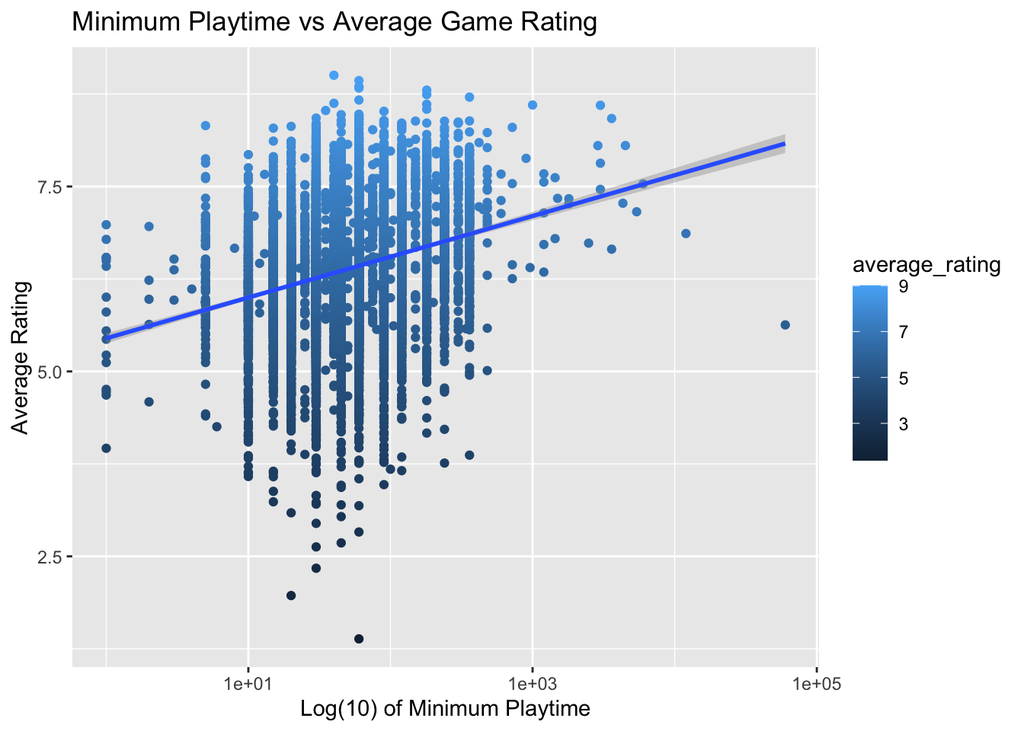

```r
#First I want to make a plot addressing the main research question, the relationship between minimum playtime and average rating. Again, I made use of Dr. Minnier and Dr. Niederhausen's slides from their "An Introduction to R and RStudio for Exploratory Data Analysis" pt 2 presentation, and also the "Data Visualization with ggplot2 : : CHEAT SHEET" available through the help function in RStudio. I also used the Part 4 lecture from this course to help with my code.
ggplot(data = BoardGames_V4,
       aes(x = min_playtime, y = average_rating, color = average_rating)) +
  geom_point() +
  geom_smooth(method = lm) +
  scale_x_log10() +
  labs(title = "Minimum Playtime vs Average Game Rating", x = "Log(10) of Minimum Playtime", y = "Average Rating")
```

I used a log scale for the x-axis to fit all the data in without having to remove outliers, and graphically added a linear model to visualize the data trend.

**Boxplots of Minimum Playtime vs Average Game Rating by Age Group** Next, I wanted to look at my age-category subsets:

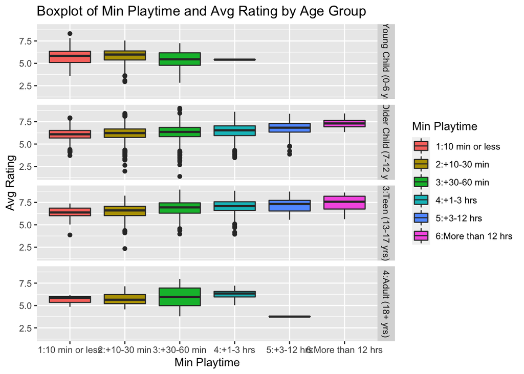

```r
# For this boxplot, I used the Part 3 lecture and Part 3 assignment for assistance with the code, as well as the "Data Visualization with ggplot2 : : CHEAT SHEET" available through the help function in RStudio
ggplot(BoardGames_V4) +

  aes(x = min_play_categories,
      y = average_rating,
      fill = min_play_categories) +

  geom_boxplot() +

  facet_grid(rows = vars(min_age_categories)) +

  labs(title ="Boxplot of Min Playtime and Avg Rating by Age Group", x = "Min Playtime", y = "Avg Rating") +

  scale_fill_discrete(name = "Min Playtime")
```

## Final Summary (10 points)

> *Summarize your research question and findings below.*

My original questions were how does minimum length of play affect average rating of board game on Board Game Geek? How does this change if you stratify by minimum age of player? What I found was that overall, the longer the minimum length of play, the higher the mean of the average rating on Board Game Geek (when excluding the games with no listed minimum playtime due to not knowing if those were the equivilent of NA values). However, when I broke the data down by age group, I found that while this trend held true for Older Children and Teens, it did not as much for Young Children and Adults. For adults the preferred length of gameplay was more than 1 and up to 3 hours, and for young children the preferred length of gameplay was more than 10 and up to 30 minutes. However, it is important to mention that there were very few observations in the adult group, and by far the most observations in the older child and teen groups, so that could certainly be part of the reason why the overall trend followed the pattern of those two groups.

> *Are your findings what you expected? Why or Why not?*

My findings for the overall data were not what I expected; I had expected people to prefer shorter games but the overall trend showed the opposite, the longer the game, the higher the average rating. However, I had also hypothesized that young children’s shorter attention spans would cause them to prefer shorter games, and this did hold pretty true; the games that were less than 10 minutes, or 10-30 minutes both had higher ratings than longer games in the Young Child category. I had hypothesized that attention span would keep going up as players got older, and generally for the older children and teens, longer games were preferred. There was little data for the adult minimum age group, and since there was only one game longer than +1-3 hrs, it is hard to conclude whether adults dislike very long games; for adults the preferred game length was +1-3 hrs.